```python
import pandas as pd
import matplotlib.pyplot as plt
import seaborn as sns
```

```python
data = pd.read_csv("Fhir.csv")
data.shape
```

```
(205, 4)
```

```python
data.head(15)
```

|  | year | active | name | country |
| --- | --- | --- | --- | --- |
| 0 | 2015 | Yes | Argonaut Phase 2 Implementation & Testing - De... | US |
| 1 | 2010 | Yes | SMART Health IT | US |
| 2 | 2015 | Yes | HL7 FHIR Conformance and Interoperability Test... | US |
| 3 | 2015 | Yes | AEGIS WildFHIR Client and Server | US |
| 4 | 2015 | Yes | Semantic Interoperability Framework (SIF) | US |
| 5 | 2015 | Yes | Semantic Interoperability Framework (SIF) | US |
| 6 | 2014 | Yes | Crucible: A FHIR Testing Tool | US |
| 7 | 2013 | Yes | PatientPing: Real-Time ADT Notifications | US |
| 8 | 2014 | Yes | Advancing Functional Interoperability through ... | US |
| 9 | 2010 | Yes | Allscripts Developer Program (ADP) | US |
| 10 | 2015 | Yes | Carequality Interoperability Framework | US |
| 11 | 2017 | Yes | FHIR-Based Healthcare Provider Directory | US |
| 12 | 2012 | Yes | The Sequoia Project | US |
| 13 | 2009 | Yes | eHealth Exchange | US |
| 14 | 2006 | Yes | Total Interoperability Today, with MedKaz® | US |

Выведем общее количество проектов по странам:

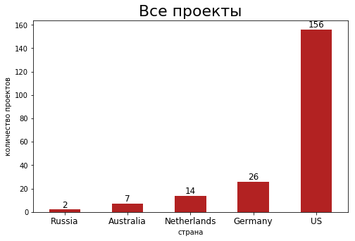

```python
fig,ax=plt.subplots(figsize=(8,5))
x=data.country.value_counts(ascending=True)
x.plot( kind='bar',width = 0.5,color= 'firebrick',zorder=2,ax=ax)

for i in range(len(x)):
    ax.text(i,x[i],x[i],horizontalalignment='center',verticalalignment='bottom',fontsize=12)
plt.xlabel('страна')
ax.set_title('Все проекты',fontdict={'size':22})
plt.ylabel('количество проектов')
plt.xticks(rotation=0,fontsize=12)
```

```python
data.country.value_counts(ascending=True)
```

```
Russia           2
Australia        7
Netherlands     14
Germany         26
US             156
Name: country, dtype: int64
```

Данный график показывает число активных проектов в США по годам:

```python
data_active=data[data.active=='Yes'].copy()
```

```python
data_active['year'] = data_active.year.astype('str')
```

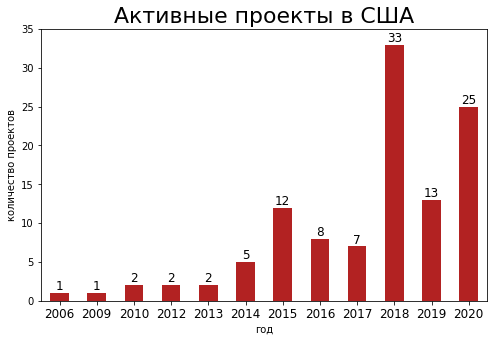

```python
x=data_active[data_active.country == 'US'].year.value_counts().sort_index()


fig,ax=plt.subplots(figsize=(8,5))
x.plot( kind='bar',width = 0.5,color= 'firebrick',zorder=2,ax=ax)

for i in range(len(x)):
    ax.text(i,x[i],x[i],horizontalalignment='center',verticalalignment='bottom',fontsize=12)
plt.xlabel('год')
ax.set_title('Активные проекты в США',fontdict={'size':22})
plt.ylabel('количество проектов')
ax.set( ylim=(0, 35))
plt.xticks(rotation=0,fontsize=12)
```

```python
data_activeUS=data_active[data_active.country == 'US'].year.value_counts().sort_index()
```

Данный график показывает число активных проектов в Австралии по годам:

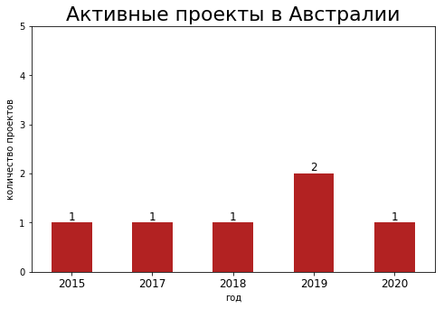

```python
x=data_active[data_active.country == 'Australia'].year.value_counts().sort_index()


fig,ax=plt.subplots(figsize=(8,5))
x.plot( kind='bar',width = 0.5,color= 'firebrick',zorder=2,ax=ax)

for i in range(len(x)):
    ax.text(i,x[i],x[i],horizontalalignment='center',verticalalignment='bottom',fontsize=12)
plt.xlabel('год')
ax.set_title('Активные проекты в Австралии',fontdict={'size':22})
plt.ylabel('количество проектов')
ax.set( ylim=(0, 5))
plt.xticks(rotation=0,fontsize=12)
```

```python
data_activeAU = data_active[data_active.country == 'Australia'].year.value_counts().sort_index()
```

Данный график показывает число активных проектов в Германии по годам:

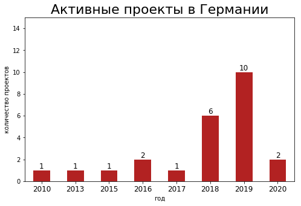

```python
x=data_active[data_active.country == 'Germany'].year.value_counts().sort_index()


fig,ax=plt.subplots(figsize=(8,5))
x.plot( kind='bar',width = 0.5,color= 'firebrick',zorder=2,ax=ax)

for i in range(len(x)):
    ax.text(i,x[i],x[i],horizontalalignment='center',verticalalignment='bottom',fontsize=12)
plt.xlabel('год')
ax.set_title('Активные проекты в Германии',fontdict={'size':22})
plt.ylabel('количество проектов')
ax.set( ylim=(0, 15))
plt.xticks(rotation=0,fontsize=12)
```

```python
data_activeGermany=data_active[data_active.country == 'Germany'].year.value_counts().sort_index()
```

Данный график показывает число активных проектов в Нидерландах по годам:

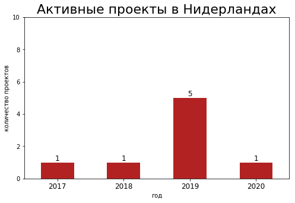

```python
x=data_active[data_active.country == 'Netherlands'].year.value_counts().sort_index()


fig,ax=plt.subplots(figsize=(8,5))
x.plot( kind='bar',width = 0.5,color= 'firebrick',zorder=2,ax=ax)

for i in range(len(x)):
    ax.text(i,x[i],x[i],horizontalalignment='center',verticalalignment='bottom',fontsize=12)
plt.xlabel('год')
ax.set_title('Активные проекты в Нидерландах',fontdict={'size':22})
plt.ylabel('количество проектов')
ax.set( ylim=(0, 10))
plt.xticks(rotation=0,fontsize=12)
```

```python
data_activeNetherlands=data_active[data_active.country == 'Netherlands'].year.value_counts().sort_index()
```

Данный график показывает число активных проектов в России по годам:

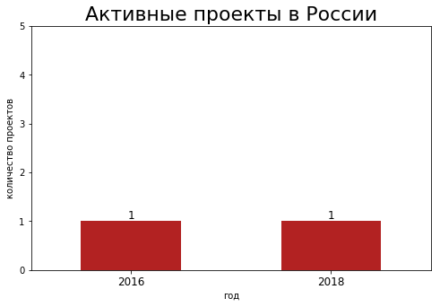

```python
x=data_active[data_active.country == 'Russia'].year.value_counts().sort_index()


fig,ax=plt.subplots(figsize=(8,5))
x.plot( kind='bar',width = 0.5,color= 'firebrick',zorder=2,ax=ax)

for i in range(len(x)):
    ax.text(i,x[i],x[i],horizontalalignment='center',verticalalignment='bottom',fontsize=12)
plt.xlabel('год')
ax.set_title('Активные проекты в России',fontdict={'size':22})
plt.ylabel('количество проектов')
ax.set( ylim=(0, 5))
plt.xticks(rotation=0,fontsize=12)
```

```python
data_activeRussia=data_active[data_active.country == 'Russia'].year.value_counts().sort_index()
```

Данный график показывает число завершенных проектов в США по годам:

```python
data_non_active=data[data.active=='No'].copy()
data_non_active['year']= data_non_active.year.astype('str')
```

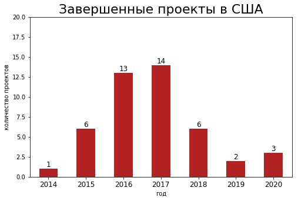

```python
x=data_non_active[data_non_active.country == 'US'].year.value_counts().sort_index()


fig,ax=plt.subplots(figsize=(8,5))
x.plot( kind='bar',width = 0.5,color= 'firebrick',zorder=2,ax=ax)

for i in range(len(x)):
    ax.text(i,x[i],x[i],horizontalalignment='center',verticalalignment='bottom',fontsize=12)
plt.xlabel('год')
ax.set_title('Завершенные проекты в США',fontdict={'size':22})
plt.ylabel('количество проектов')
ax.set( ylim=(0, 20))
plt.xticks(rotation=0,fontsize=12)
```

```python
data_non_active[data_non_active.country == 'US'].year.value_counts().sort_index()
```

```
2014     1
2015     6
2016    13
2017    14
2018     6
2019     2
2020     3
Name: year, dtype: int64
```

Данный график показывает число завершенных проектов в Австралии по годам:

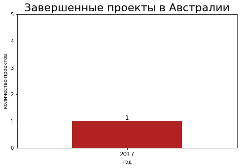

```python
x=data_non_active[data_non_active.country == 'Australia'].year.value_counts().sort_index()


fig,ax=plt.subplots(figsize=(8,5))
x.plot( kind='bar',width = 0.5,color= 'firebrick',zorder=2,ax=ax)

for i in range(len(x)):
    ax.text(i,x[i],x[i],horizontalalignment='center',verticalalignment='bottom',fontsize=12)
plt.xlabel('год')
ax.set_title('Завершенные проекты в Австралии',fontdict={'size':22})
plt.ylabel('количество проектов')
ax.set( ylim=(0, 5))
plt.xticks(rotation=0,fontsize=12)
```

```python
data_non_active[data_non_active.country == 'Australia'].year.value_counts().sort_index()
```

```
2017    1
Name: year, dtype: int64
```

Данный график показывает число завершенных проектов в Германии по годам:

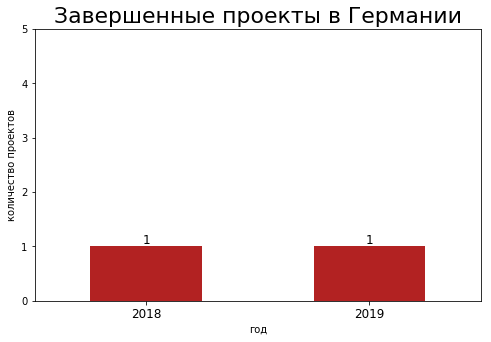

```python
x=data_non_active[data_non_active.country == 'Germany'].year.value_counts().sort_index()


fig,ax=plt.subplots(figsize=(8,5))
x.plot( kind='bar',width = 0.5,color= 'firebrick',zorder=2,ax=ax)

for i in range(len(x)):
    ax.text(i,x[i],x[i],horizontalalignment='center',verticalalignment='bottom',fontsize=12)
plt.xlabel('год')
ax.set_title('Завершенные проекты в Германии',fontdict={'size':22})
plt.ylabel('количество проектов')
ax.set( ylim=(0, 5))
plt.xticks(rotation=0,fontsize=12)
```

```python
data_non_active[data_non_active.country == 'Germany'].year.value_counts().sort_index()
```

```
2018    1
2019    1
Name: year, dtype: int64
```

Данный график показывает число завершенных проектов в Нидерландах по годам:

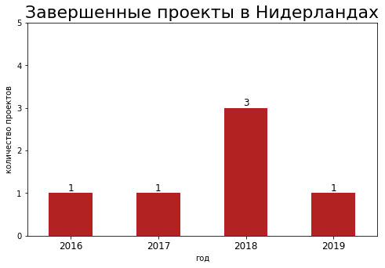

```python
x=data_non_active[data_non_active.country == 'Netherlands'].year.value_counts().sort_index()


fig,ax=plt.subplots(figsize=(8,5))
x.plot( kind='bar',width = 0.5,color= 'firebrick',zorder=2,ax=ax)

for i in range(len(x)):
    ax.text(i,x[i],x[i],horizontalalignment='center',verticalalignment='bottom',fontsize=12)
plt.xlabel('год')
ax.set_title('Завершенные проекты в Нидерландах',fontdict={'size':22})
plt.ylabel('количество проектов')
ax.set( ylim=(0, 5))
plt.xticks(rotation=0,fontsize=12)
```

```python
data_non_active[data_non_active.country == 'Netherlands'].year.value_counts().sort_index()
```

```
2016    1
2017    1
2018    3
2019    1
Name: year, dtype: int64
```

Данный график показывает число активных проектов по странам по годам:

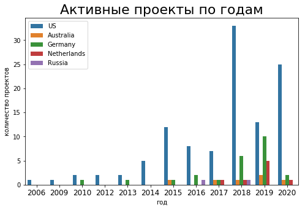

```python
fig,ax = plt.subplots( figsize=(8, 5))
sns.countplot(x=data_active['year'], data=data_active, hue=data_active['country'],ax=ax)


ax.set_title('Активные проекты по годам',fontdict={'size':22})
plt.xlabel('год')
plt.ylabel('количество проектов')
plt.xticks(rotation=0,fontsize=12)
plt.legend(loc='upper left')
plt.show()
```

```python
data_active['year'].value_counts()
```

```
2018    42
2019    30
2020    29
2015    14
2016    11
2017    10
2014     5
2010     3
2013     3
2012     2
2006     1
2009     1
Name: year, dtype: int64
```

Данный график показывает число завершенных проектов по странам по годам:

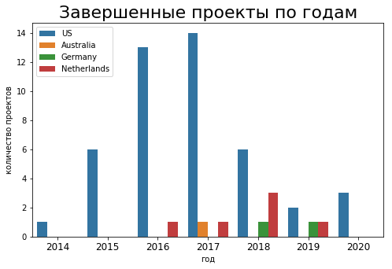

```python
fig,ax = plt.subplots( figsize=(8, 5))
sns.countplot(x=data_non_active['year'], data=data_non_active, hue=data_non_active['country'],ax=ax)

ax.set_title('Завершенные проекты по годам',fontdict={'size':22})
plt.xlabel('год')
plt.ylabel('количество проектов')
plt.xticks(rotation=0,fontsize=12)
plt.legend(loc='upper left')
plt.show()
```

```python
data2 = pd.read_csv("Fhir2.csv")
data2.shape
```

```
(5, 5)
```

```python
data2
```

|  | country | the_number_of_organizations | the_number_of_working_groups | the_number_of_clinics | the_whole_number_of_clinics |
| --- | --- | --- | --- | --- | --- |
| 0 | US | 105 | 37 | 5200 | 6000 |
| 1 | Australia | 15 | 7 | 305 | 1350 |
| 2 | Germany | 100 | 2 | 70 | 2000 |
| 3 | Russia | 2 | 2 | 330 | 14500 |
| 4 | Netherlands | 5 | 2 | 27 | 545 |

Данные из датасета представлены ниже в виде графиков:

График количества организаций:

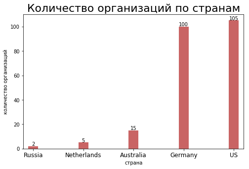

```python
df = data2[['country', 'the_number_of_organizations']].groupby('country').apply(lambda x: x)
df.sort_values('the_number_of_organizations', inplace=True)
df.reset_index(inplace=True)

import matplotlib.patches as patches

fig, ax = plt.subplots(figsize=(8,5))
ax.vlines(x=df.index, ymin=0, ymax=df.the_number_of_organizations, color='firebrick', alpha=0.7, linewidth=20)

for i, the_number_of_organizations in enumerate(df.the_number_of_organizations):
    ax.text(i, the_number_of_organizations+0.5, round(the_number_of_organizations), horizontalalignment='center')


ax.set_title('Количество организаций по странам', fontdict={'size':22})
ax.set(ylabel='количество организаций', ylim=(0, 110))
plt.xlabel('страна')
plt.xticks(df.index, df.country,  fontsize=12)

plt.show()
```

График количества рабочих групп:

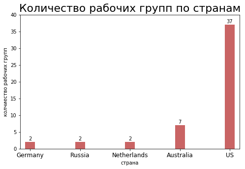

```python
df = data2[['country', 'the_number_of_working_groups']].groupby('country').apply(lambda x: x)
df.sort_values('the_number_of_working_groups', inplace=True)
df.reset_index(inplace=True)

import matplotlib.patches as patches

fig, ax = plt.subplots(figsize=(8,5))
ax.vlines(x=df.index, ymin=0, ymax=df.the_number_of_working_groups, color='firebrick', alpha=0.7, linewidth=20)

for i, the_number_of_working_groups in enumerate(df.the_number_of_working_groups):
    ax.text(i, the_number_of_working_groups+0.5, round(the_number_of_working_groups), horizontalalignment='center')


ax.set_title('Количество рабочих групп по странам', fontdict={'size':22})
ax.set(ylabel='колчиество рабочих групп', ylim=(0, 40))
plt.xlabel('страна')
plt.xticks(df.index, df.country,  fontsize=12)

plt.show()
```

```python
x=data2.sort_values('the_number_of_clinics')
```

График количества клиник:

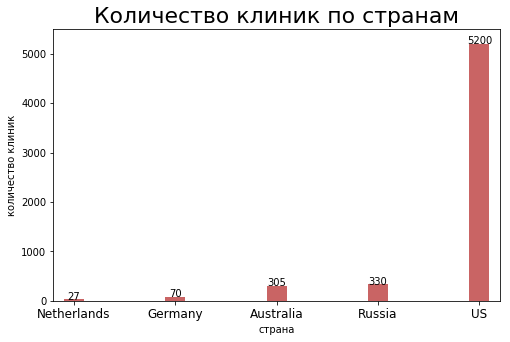

```python
df = data2[['country', 'the_number_of_clinics']].groupby('country').apply(lambda x: x)
df.sort_values('the_number_of_clinics', inplace=True)
df.reset_index(inplace=True)

import matplotlib.patches as patches

fig, ax = plt.subplots(figsize=(8,5))
ax.vlines(x=df.index, ymin=0, ymax=df.the_number_of_clinics, color='firebrick', alpha=0.7, linewidth=20)

for i, the_number_of_clinics in enumerate(df.the_number_of_clinics):
    ax.text(i, the_number_of_clinics+1, round(the_number_of_clinics), horizontalalignment='center')


ax.set_title('Количество клиник по странам', fontdict={'size':22})
ax.set(ylabel='количество клиник', ylim=(0, 5500))
plt.xlabel('страна')
plt.xticks(df.index, df.country,  fontsize=12)

plt.show()
```

```python
data2['percentage_fhir_clinics_number']=data2['the_number_of_clinics']*100/data2['the_whole_number_of_clinics']
```

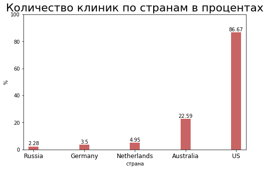

```python
df = data2[['country', 'percentage_fhir_clinics_number']].groupby('country').apply(lambda x: x)
df.sort_values('percentage_fhir_clinics_number', inplace=True)
df.reset_index(inplace=True)

import matplotlib.patches as patches

fig, ax = plt.subplots(figsize=(8,5))
ax.vlines(x=df.index, ymin=0, ymax=df.percentage_fhir_clinics_number, color='firebrick', alpha=0.7, linewidth=20)

for i, percentage_fhir_clinics_number in enumerate(df.percentage_fhir_clinics_number):
    ax.text(i, percentage_fhir_clinics_number+1, round(percentage_fhir_clinics_number,2), horizontalalignment='center')


ax.set_title('Количество клиник по странам в процентах', fontdict={'size':22})
ax.set(ylabel='%', ylim=(0, 100))
plt.xlabel('страна')
plt.xticks(df.index, df.country,  fontsize=12)

plt.show()
```

```python
data3 = pd.read_csv("Fhir3.csv")
data3.shape
```

```
(27, 3)
```

```python
data3
```

|  | country | year | the_number_of_conferences |
| --- | --- | --- | --- |
| 0 | US | 2012 | 1 |
| 1 | US | 2013 | 4 |
| 2 | US | 2014 | 3 |
| 3 | US | 2015 | 3 |
| 4 | US | 2016 | 3 |
| 5 | US | 2017 | 4 |
| 6 | US | 2018 | 3 |
| 7 | US | 2019 | 3 |
| 8 | US | 2020 | 3 |
| 9 | Australia | 2013 | 1 |
| 10 | Australia | 2014 | 1 |
| 11 | Australia | 2015 | 1 |
| 12 | Australia | 2016 | 2 |
| 13 | Australia | 2017 | 6 |
| 14 | Australia | 2018 | 2 |
| 15 | Australia | 2019 | 3 |
| 16 | Australia | 2020 | 1 |
| 17 | Germany | 2016 | 1 |
| 18 | Germany | 2017 | 1 |
| 19 | Germany | 2018 | 1 |
| 20 | Germany | 2019 | 1 |
| 21 | Russia | 2016 | 1 |
| 22 | Russia | 2018 | 1 |
| 23 | Russia | 2019 | 1 |
| 24 | Netherlands | 2018 | 1 |
| 25 | Netherlands | 2019 | 2 |
| 26 | Netherlands | 2020 | 1 |

Число конференций по годам в США:

```python
data3US=data3[data3.country=='US'].copy()
```

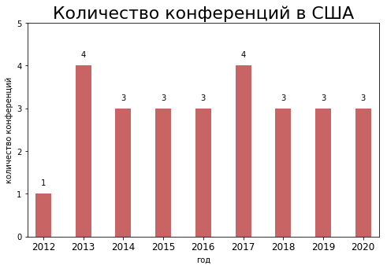

```python
df = data3US[['year', 'the_number_of_conferences']].groupby('year').apply(lambda x: x)
df.sort_values('year', inplace=True)
df.reset_index(inplace=True)

import matplotlib.patches as patches

fig, ax = plt.subplots(figsize=(8,5))
ax.vlines(x=df.index, ymin=0, ymax=df.the_number_of_conferences, color='firebrick', alpha=0.7, linewidth=20)

for i, the_number_of_conferences in enumerate(df.the_number_of_conferences):
    ax.text(i, the_number_of_conferences+0.2, round(the_number_of_conferences), horizontalalignment='center')


ax.set_title('Количество конференций в США', fontdict={'size':22})
ax.set(ylabel='количество конференций', ylim=(0, 5))
plt.xlabel('год')
plt.xticks(df.index, df.year,  fontsize=12)

plt.show()
```

Число конференций по годам в Австралии:

```python
data3Australia=data3[data3.country=='Australia'].copy()
```

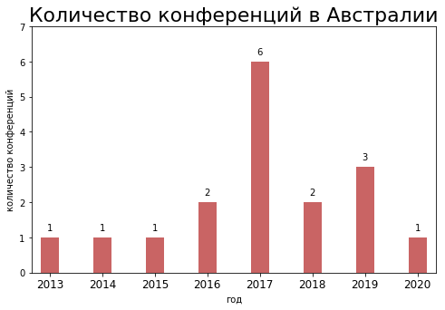

```python
df = data3Australia[['year', 'the_number_of_conferences']].groupby('year').apply(lambda x: x)
df.sort_values('year', inplace=True)
df.reset_index(inplace=True)

import matplotlib.patches as patches

fig, ax = plt.subplots(figsize=(8,5))
ax.vlines(x=df.index, ymin=0, ymax=df.the_number_of_conferences, color='firebrick', alpha=0.7, linewidth=20)

for i, the_number_of_conferences in enumerate(df.the_number_of_conferences):
    ax.text(i, the_number_of_conferences+0.2, round(the_number_of_conferences), horizontalalignment='center')


ax.set_title('Количество конференций в Австралии', fontdict={'size':22})
ax.set(ylabel='количество конференций', ylim=(0, 7))
plt.xlabel('год')
plt.xticks(df.index, df.year,  fontsize=12)

plt.show()
```

Число конференций по годам в Германии:

```python
data3Germany=data3[data3.country=='Germany'].copy()
```

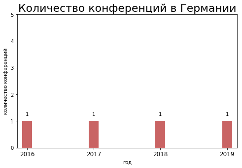

```python
df = data3Germany[['year', 'the_number_of_conferences']].groupby('year').apply(lambda x: x)
df.sort_values('year', inplace=True)
df.reset_index(inplace=True)

import matplotlib.patches as patches

fig, ax = plt.subplots(figsize=(8,5))
ax.vlines(x=df.index, ymin=0, ymax=df.the_number_of_conferences, color='firebrick', alpha=0.7, linewidth=20)

for i, the_number_of_conferences in enumerate(df.the_number_of_conferences):
    ax.text(i, the_number_of_conferences+0.2, round(the_number_of_conferences), horizontalalignment='center')


ax.set_title('Количество конференций в Германии', fontdict={'size':22})
ax.set(ylabel='количество конференций', ylim=(0, 5))
plt.xlabel('год')
plt.xticks(df.index, df.year,  fontsize=12)

plt.show()
```

Число конференций по годам в Нидерландах:

```python
data3Netherlands=data3[data3.country=='Netherlands'].copy()
```

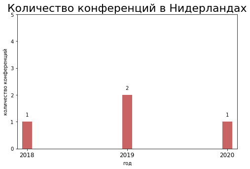

```python
df = data3Netherlands[['year', 'the_number_of_conferences']].groupby('year').apply(lambda x: x)
df.sort_values('year', inplace=True)
df.reset_index(inplace=True)

import matplotlib.patches as patches

fig, ax = plt.subplots(figsize=(8,5))
ax.vlines(x=df.index, ymin=0, ymax=df.the_number_of_conferences, color='firebrick', alpha=0.7, linewidth=20)

for i, the_number_of_conferences in enumerate(df.the_number_of_conferences):
    ax.text(i, the_number_of_conferences+0.2, round(the_number_of_conferences), horizontalalignment='center')


ax.set_title('Количество конференций в Нидерландах', fontdict={'size':22})
ax.set(ylabel='количество конференций', ylim=(0, 5))
plt.xlabel('год')
plt.xticks(df.index, df.year,  fontsize=12)

plt.show()
```

Число конференций по годам в России:

```python
data3Russia=data3[data3.country=='Russia'].copy()
```

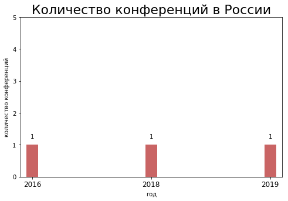

```python
df = data3Russia[['year', 'the_number_of_conferences']].groupby('year').apply(lambda x: x)
df.sort_values('year', inplace=True)
df.reset_index(inplace=True)

import matplotlib.patches as patches

fig, ax = plt.subplots(figsize=(8,5))
ax.vlines(x=df.index, ymin=0, ymax=df.the_number_of_conferences, color='firebrick', alpha=0.7, linewidth=20)

for i, the_number_of_conferences in enumerate(df.the_number_of_conferences):
    ax.text(i, the_number_of_conferences+0.2, round(the_number_of_conferences), horizontalalignment='center')


ax.set_title('Количество конференций в России', fontdict={'size':22})
ax.set(ylabel='количество конференций', ylim=(0, 5))
plt.xlabel('год')
plt.xticks(df.index, df.year,  fontsize=12)

plt.show()
```

Подготовим датасеты для дальнейшего анализа путем преобразованияих в новые:

```python
data_activeUS.index = data_activeUS.index.astype(int)
```

```python
data_scatterUS = pd.DataFrame({'year': data_activeUS.index, 'projects':data_activeUS.values})
```

```python
data_scatterUS['country']='US'
```

```python
data_scatterUS=pd.merge(data_scatterUS,data3US,on='year',how='outer')
```

```python
data_scatterUS=data_scatterUS.drop(['country_y'],axis=1)
```

```python
data_scatterUS=data_scatterUS.fillna(0)
```

```python
data_activeAU.index = data_activeAU.index.astype(int)
```

```python
data_scatterAU=pd.DataFrame({'year': data_activeAU.index, 'projects':data_activeAU.values})
data_scatterAU['country']='Australia'
```

```python
data_scatterAU=pd.merge(data_scatterAU,data3Australia,on='year',how='outer')
```

```python
data_scatterAU=data_scatterAU.drop(['country_y'],axis=1)
```

```python
data_scatterAU['country_x']='Australia'
```

```python
data_scatterAU=data_scatterAU.fillna(0)
```

```python
data_activeGermany.index = data_activeGermany.index.astype(int)
```

```python
data_scatterGermany=pd.DataFrame({'year': data_activeGermany.index, 'projects':data_activeGermany.values})
data_scatterGermany['country']='Germany'
```

```python
data_scatterGermany=pd.merge(data_scatterGermany,data3Germany,on='year',how='outer')
```

```python
data_scatterGermany=data_scatterGermany.drop(['country_y'],axis=1)
data_scatterGermany['country_x']='Germany'
data_scatterGermany=data_scatterGermany.fillna(0)
```

```python
data_activeNetherlands.index = data_activeNetherlands.index.astype(int)
```

```python
data_scatterNetherlands=pd.DataFrame({'year': data_activeNetherlands.index, 'projects':data_activeNetherlands.values})
data_scatterNetherlands['country']='Netherlands'
data_scatterNetherlands=pd.merge(data_scatterNetherlands,data3Netherlands,on='year',how='outer')
```

```python
data_scatterNetherlands=data_scatterNetherlands.drop(['country_y'],axis=1)
data_scatterNetherlands['country_x']='Netherlands'
data_scatterNetherlands=data_scatterNetherlands.fillna(0)
```

```python
data_activeRussia.index = data_activeRussia.index.astype(int)
```

```python
data_scatterRussia=pd.DataFrame({'year': data_activeRussia.index, 'projects':data_activeRussia.values})
data_scatterRussia['country']='Russia'
data_scatterRussia=pd.merge(data_scatterRussia,data3Russia,on='year',how='outer')
```

```python
data_scatterRussia=data_scatterRussia.drop(['country_y'],axis=1)
data_scatterRussia['country_x']='Russia'
data_scatterRussia=data_scatterRussia.fillna(0)
```

```python
data_new=pd.concat([data_scatterAU,data_scatterUS,data_scatterGermany,data_scatterNetherlands,data_scatterRussia])
```

Получаем необходимый датасет:

```python
data_new
```

|  | year | projects | country_x | the_number_of_conferences |
| --- | --- | --- | --- | --- |
| 0 | 2015 | 1.0 | Australia | 1.0 |
| 1 | 2017 | 1.0 | Australia | 6.0 |
| 2 | 2018 | 1.0 | Australia | 2.0 |
| 3 | 2019 | 2.0 | Australia | 3.0 |
| 4 | 2020 | 1.0 | Australia | 1.0 |
| 5 | 2013 | 0.0 | Australia | 1.0 |
| 6 | 2014 | 0.0 | Australia | 1.0 |
| 7 | 2016 | 0.0 | Australia | 2.0 |
| 0 | 2006 | 1.0 | US | 0.0 |
| 1 | 2009 | 1.0 | US | 0.0 |
| 2 | 2010 | 2.0 | US | 0.0 |
| 3 | 2012 | 2.0 | US | 1.0 |
| 4 | 2013 | 2.0 | US | 4.0 |
| 5 | 2014 | 5.0 | US | 3.0 |
| 6 | 2015 | 12.0 | US | 3.0 |
| 7 | 2016 | 8.0 | US | 3.0 |
| 8 | 2017 | 7.0 | US | 4.0 |
| 9 | 2018 | 33.0 | US | 3.0 |
| 10 | 2019 | 13.0 | US | 3.0 |
| 11 | 2020 | 25.0 | US | 3.0 |
| 0 | 2010 | 1.0 | Germany | 0.0 |
| 1 | 2013 | 1.0 | Germany | 0.0 |
| 2 | 2015 | 1.0 | Germany | 0.0 |
| 3 | 2016 | 2.0 | Germany | 1.0 |
| 4 | 2017 | 1.0 | Germany | 1.0 |
| 5 | 2018 | 6.0 | Germany | 1.0 |
| 6 | 2019 | 10.0 | Germany | 1.0 |
| 7 | 2020 | 2.0 | Germany | 0.0 |
| 0 | 2017 | 1.0 | Netherlands | 0.0 |
| 1 | 2018 | 1.0 | Netherlands | 1.0 |
| 2 | 2019 | 5.0 | Netherlands | 2.0 |
| 3 | 2020 | 1.0 | Netherlands | 1.0 |
| 0 | 2016 | 1.0 | Russia | 1.0 |
| 1 | 2018 | 1.0 | Russia | 1.0 |
| 2 | 2019 | 0.0 | Russia | 1.0 |

Построим график зависимости количества проведенных конференций и активных проектов:

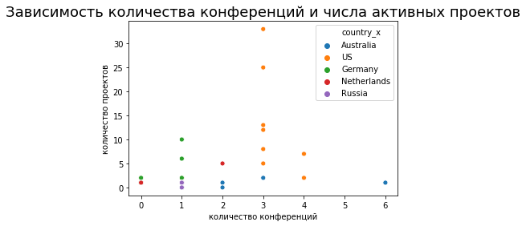

```python
ax = sns.scatterplot(x="the_number_of_conferences", y="projects",hue='country_x', data=data_new)
ax.set_title('Зависимость количества конференций и числа активных проектов', fontdict={'size':18})
plt.xlabel('количество конференций')
plt.ylabel('количество проектов')
```

Создадим еще один датасет из имеющихся:

```python
data_scatter=pd.DataFrame({'country': data.country.value_counts().index, 'projects':data.country.value_counts().values})
```

```python
data_scatter=pd.merge(data_scatter,data2,on='country')
```

```python
data_scatter
```

|  | country | projects | the_number_of_organizations | the_number_of_working_groups | the_number_of_clinics | the_whole_number_of_clinics | percentage_fhir_clinics_number |
| --- | --- | --- | --- | --- | --- | --- | --- |
| 0 | US | 156 | 105 | 37 | 5200 | 6000 | 86.666667 |
| 1 | Germany | 26 | 100 | 2 | 70 | 2000 | 3.500000 |
| 2 | Netherlands | 14 | 5 | 2 | 27 | 545 | 4.954128 |
| 3 | Australia | 7 | 15 | 7 | 305 | 1350 | 22.592593 |
| 4 | Russia | 2 | 2 | 2 | 330 | 14500 | 2.275862 |

Построим график зависимости общего числа проектов и количества клиник по странам:

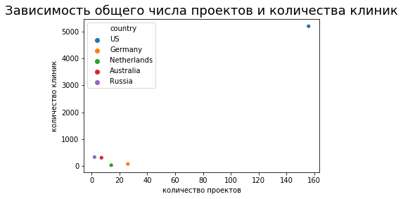

```python
ax = sns.scatterplot(x="projects", y="the_number_of_clinics",hue='country', data=data_scatter)
ax.set_title('Зависимость общего числа проектов и количества клиник', fontdict={'size':18})
plt.xlabel('количество проектов')
plt.ylabel('количество клиник')
```

Безусловно, США является лидером. Теперь посмотрим эту же зависимость только для других стран без учета США:

```python
data_scatter=data_scatter.drop([0])
```

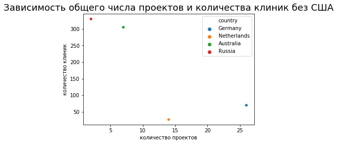

```python
ax = sns.scatterplot(x="projects", y="the_number_of_clinics",hue='country', data=data_scatter)
ax.set_title('Зависимость общего числа проектов и количества клиник без США', fontdict={'size':18})
plt.xlabel('количество проектов')
plt.ylabel('количество клиник')
```

Рассмотрим датасет с ценами платформ:

```python
data4 = pd.read_csv("Fhir4.csv")
data.shape
```

```
(205, 4)
```

```python
data4
```

|  | platform | Area | price |
| --- | --- | --- | --- |
| 0 | Microsoft Azure Api for FHIR | Southeast Asia | 655.17 |
| 1 | Microsoft Azure Api for FHIR | West Europe | 571.36 |
| 2 | Microsoft Azure Api for FHIR | US | 571.36 |
| 3 | Cloud Healthcare API | US | 511.20 |
| 4 | Cloud Healthcare API | West Europe | 408.90 |
| 5 | Cloud Healthcare API | Southeast Asia | 408.90 |
| 6 | Amazon Comprehend Medical | Southeast Asia | 260.00 |
| 7 | Amazon Comprehend Medical | West Europe | 260.00 |
| 8 | Amazon Comprehend Medical | US | 260.00 |

Построим график зависимости цены от платформы по областям:

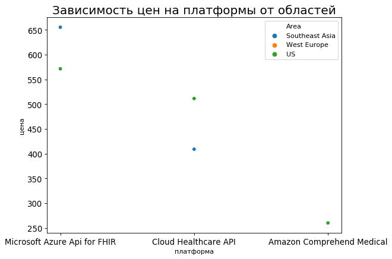

```python
fig, ax = plt.subplots(figsize=(8,6),dpi= 80, facecolor='w', edgecolor='k')
ax = sns.scatterplot(x="platform", y="price",hue='Area', data=data4)
ax.set_title('Зависимость цен на платформы от областей', fontdict={'size':18})
plt.xlabel('платформа')
plt.ylabel('цена')
plt.xticks(fontsize=12); plt.yticks(fontsize=12)
```

Построим общий график цен платформ по областям:

```python
data4US=data4[data4.Area == 'US'].price.values
```

```python
data4Asia=data4[data4.Area == 'Southeast Asia'].price.values
```

```python
data4Europe=data4[data4.Area == 'West Europe'].price.values
```

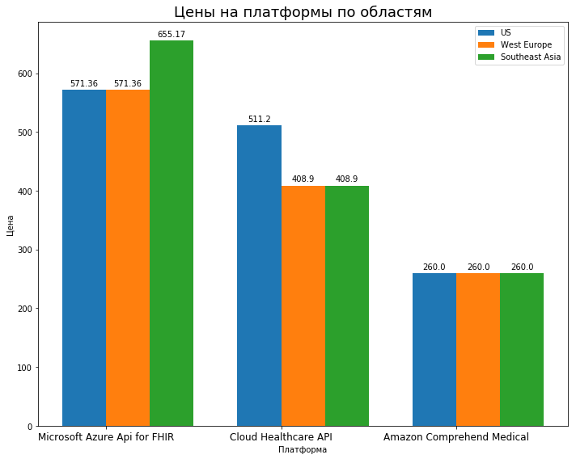

```python
import numpy as np
labels = data4.platform.value_counts().index
new_labels=[]
for i in labels:
    new_labels.append(i)



x = np.arange(len(new_labels))  # the label locations
width = 0.25  # the width of the bars

fig, ax = plt.subplots(figsize=(10,8))
rects1 = ax.bar(x-width/2, data4US, width, label='US')
rects2 = ax.bar(x+width/2, data4Europe, width, label='West Europe')
rects3 = ax.bar(x+width+width/2, data4Asia, width, label='Southeast Asia')

ax.set_ylabel('Цена')
ax.set_xlabel('Платформа')
ax.set_title('Цены на платформы по областям',fontdict={'size':18})
ax.set_xticks(x)
ax.set_xticklabels(labels,fontsize=12)
ax.legend()


def autolabel(rects):
    for rect in rects:
        height = rect.get_height()
        ax.annotate('{}'.format(height),
                    xy=(rect.get_x() + rect.get_width() / 2, height),
                    xytext=(0, 3),
                    textcoords="offset points",
                    ha='center', va='bottom')


autolabel(rects1)
autolabel(rects2)
autolabel(rects3)

fig.tight_layout()

plt.show()
```